# Introduction to programming in R

Julia Rühle & Leone Albinati

# 1 Course organization

> **Day 1 (27th of November):**
> - Introduction to R and Rstudio
> - R basics: objects, paths and functions
> - The basis of reproducibility: the R script
> - Data types in R
> - Data structures: vectors, matrices and dataframes
> - Read and write files
> - Libraries and packages

> **Day 2 (28th of November):**
> - Introduction to R and Rstudio
> - R basics: objects, paths and functions
> - The basis of reproducibility: the R script
> - Data types in R
> - Data structures: vectors, matrices and dataframes
> - Read and write files
> - Libraries and packages

> **Day 3 (29th of November):**
> - Introduction to R and Rstudio
> - R basics: objects, paths and functions
> - The basis of reproducibility: the R script
> - Data types in R
> - Data structures: vectors, matrices and dataframes
> - Read and write files
> - Libraries and packages

# 2 What is R?

- R is a **programming language**: allows us to communicate with the computer, translating the computer’s code into something humans can understand and write
- Born in 1995 in Nez Zealand on top of the Statistical Programmin language S
- R is **free** and **open source**!
- It is **widely used** (especially in biology) and has a huge and active **community**
- It runs on **multiple platforms** (MacOS, Linux, Windows…)
- Through the scripting possibility, it **allows for reproducibility**
- Access through a command-line interpreter

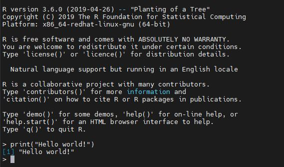

# 3 What is Rstudio?

- Rstudio is a **graphical interface** for R: it makes it easier to use the R language to communicate with the computer
- It has four panes
  1. top-left: scripts, *to garantee reproducibility*
  2. bottom-left: R console, *to communicate with the computer*
  3. top-right: objects, history and environment
  4. bottom-right: folders, plot window, help window

[figure not shown]

# 4 R basics

## 4.1 R as a calculator

R console can be used as a calculator. + (addition) - (subtraction) * (multiplication) / (division) ^ (exponential)

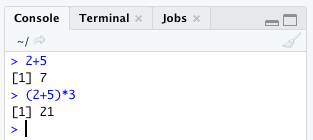

In the console, to have R interpreting your command you have to hit Enter

## 4.2 Objects: store data in R

In R, data can be stored inside objects.

### 4.2.1 Creating objects: the assignment operator

To create an object, we can use the **assignment operator <-**

```r
# Let's create an object "my_object" that stores the value 4
my_object <- 4
```

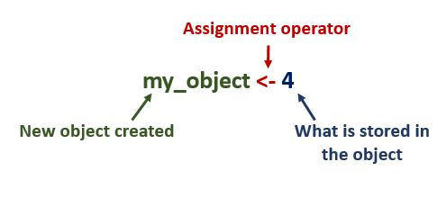

- The object we just created is now in the environment (upper-right panel)
- Tip: shortcut for <- : Alt + - (Windows) or Option + - (Mac).

### 4.2.2 Working with objects

- You can show what is stored inside the object writing its name in the console and hitting Enter
- We can use the content of the object to do operations

```r
# Let's add 7 to my_object
my_object + 7
```

- If we do so, the content of my_object is not changing (try to print my_object in the console)
- To change the content of the object, we have to re-assign

```r
# Let's modify the content of my_object
my_object <- my_object + 7
```

- We can also use multiple objects to do calculations

```r
# Let's create a new object
my_second_object <- 5
my_object * my_second_object

# let's store the result in a third object
my_third_object <- my_object * my_second_object
```

### 4.2.3 Naming objects

**Few rules to respect when naming objects**

- R is case sensitive (**My_object** is different from **my_object**)
- Cannot start with a number or contain spaces
- Avoid **special characters** except underscore
- Try to **explain the content of the object**!

## 4.3 Paths and working directory

- The path of a file/directory is its **“address”** in the computer
- It can be absolute (starts from the root) or relative (starts from where you are)
- Depending on your operating system, how the path looks could be a bit different

```r
# Windows
"C:/Users/lalbinati/Desktop/"
# MacOS and Linux
"/Users/lalbinati/Desktop/"
```

### 4.3.1 Working directory

- When you start working in R you are normally located in your home directory (Linux and MacOS).
- This is your **working directory**: this means that everything you will import or export will be automatically directed here.
- If we want to import/export something from a different directory, we will have to specify it.
- It is really important, before starting working, to **change and specify your working directory**.
- Why is this important? Normally, each project will have a different working directory, making the analysis easier and cleaner.

### 4.3.2 Checking and changing working directory from the console

To know where I am currently located, we can use the function **getwd()**

```r
# Run this command in the console and hit Enter
getwd()
```

To change the working directory, use the function setwd() and inside the brackets write the path of the new working directory

```r
# changing the working directory to the desktop
setwd("C:/Users/lalbinati/Desktop")

# check that the directory has changed
getwd()
```

We do not want to work on the Desktop (it would be really messy) so we can create a folder for the R course and move our working directory there.

Many things in Rstudio can be done from the console or using the point-and-click approach.

Let’s create a new folder where to store the material for the course.

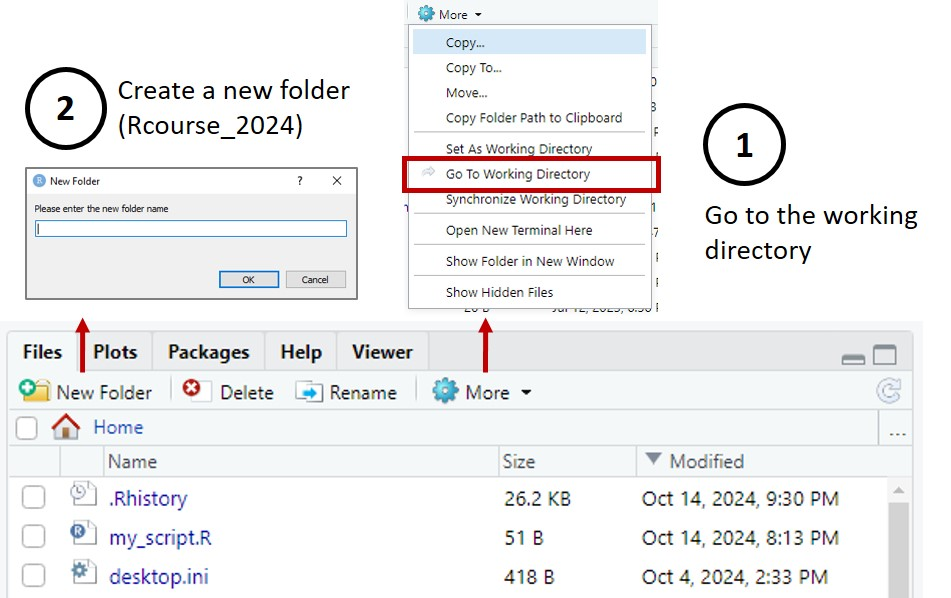

Now, let’s change the working directory to the newly created Rcourse_2024

```r
# let's use the setwd() function
# we have two options: to use the absolute path or the relative path

# where are we
getwd()

# using the absolute path
setwd("C:/Users/lalbinati/Desktop/Rcourse_2024")

# using the realtive path
setwd("Rcourse_2024")
```

Using the absolute or relative path gives the same input.

- Use **absolute paths** (e.g., “/Users/YourName/data/data.csv”) when you need to point to a file or folder that will always be in the same location on your machine, regardless of where your R script is located.
- Use **relative path**s (e.g., “data/data.csv”) when working within a project or a fixed folder structure. Relative paths are better for portability—if you move the project folder, the paths will still work as long as the folder structure remains the same.

## 4.4 Functions in R

- In R, a function is a **block of code that performs a specific task**. You can think of it as a “recipe” that takes input, does something with it, and returns an output. You normally don’t see the code behind the function, but you just get the output.
- It is easily recognizable by the **brackets**: functionname**()**

### 4.4.1 Function example

Let’s explore the **round()** function

```r
# Run this function in your console,can you guess what it does?
round(x=3.14159265358,digits=2)
```

**Click to expand**

`round()` rounds the values in its first argument to the specified number of decimal places (default 0).

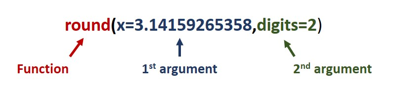

A function takes arguments (in this case x and digits)

### 4.4.2 Getting help

To know what a function does and which are its arguments, we can ask for help.

```r
# Two ways to ask for help from the console
help(round)
?round

# otherwise use the help section of the bottom-right panel
```

If this section is not helpful enough, Google it!

### 4.4.3 Managing the arguments

- Some of the arguments can be **mandatory** (without them the function does not work)
- They can be given using their names or **without names** following the order (careful with more complex-multiargument functions)
- Suggestion: try to always write the name of the arguments

```r
# Function with named arguments
round(x=3.14159265358,digits=2)

# Changing order but keeping names it does not change the output
round(digits=2,x=3.14159265358)

# Keeping only the x argument - what happens?
round(x=3.14159265358)

# Keeping only the digits argument - what happens?
round(digits=2)

# Keeping the right order and removing names
round(3.14159265358,2)

# Changing order and removing names
round(2, 3.14159265358)
```

We can also provide **objects as input arguments** for the functions

```r
# Let's define the objects we want
pi <- 3.14159265358
decimals <- 3

round(x=pi,digits=decimals)
```

We can also **assign** the output of a function to an object

```r
# Function with named arguments
pi_two_digits <- round(x=3.14159265358,digits=2)
```

# 5 R script

- The script is the basis of **reproducibility**, for you and for other people using your script
- What you write in the console will be gone once you start a new Rstudio session
- Scripting makes programming languages **much more reliable** than tools like Excel (even for tasks that could be done with Excel)

## 5.1 Create and save a script

[figure not shown]

## 5.2 The script panel

- The script panel is **different from the console!**
- What we write here **will not be run** unless we specifically decide to.
- To run something from the script panel, put the cursor on the line and press **ctrl+Enter**
- Once you have ran something, it will appear in the console together with the output
- We can also run **multiple lines together**

```r
# Write in the script panel - if you do not run the commands nothing will happen
round(x=3.14159265358,digits=2)

# we can select which lines to run or to run all together
pi_three_digits <- round(x=3.14159265358,digits=3)
pi_three_digits / 10
```

In R, everything that is followed by **#** will not be interpreted by the console